## Grouped Barplot in R

In this post, we are going to see how we can program a grouped barplot in R. We will be using R to explore data related to bike share systems for three major cities in the United States—Chicago, New York City, and Washington.

We will use data provided by Motivate, a bike-share system provider for many major cities in the United States, to answer a question about the data.

We will explore the question, “What are the counts for each user type?”.

## The Dataset

Let’s import our datasets and see what we are working with.

```r
ny = read.csv("new_york_city.csv")
wash = read.csv("washington.csv")
chi = read.csv("chicago.csv")
```

We now use the head function to see how each data frame looks like.

```r
head(ny)
```

```
##         X          Start.Time            End.Time Trip.Duration
## 1 5688089 2017-06-11 14:55:05 2017-06-11 15:08:21           795
## 2 4096714 2017-05-11 15:30:11 2017-05-11 15:41:43           692
## 3 2173887 2017-03-29 13:26:26 2017-03-29 13:48:31          1325
## 4 3945638 2017-05-08 19:47:18 2017-05-08 19:59:01           703
## 5 6208972 2017-06-21 07:49:16 2017-06-21 07:54:46           329
## 6 1285652 2017-02-22 18:55:24 2017-02-22 19:12:03           998
##             Start.Station            End.Station  User.Type Gender Birth.Year
## 1 Suffolk St & Stanton St W Broadway & Spring St Subscriber   Male       1998
## 2 Lexington Ave & E 63 St        1 Ave & E 78 St Subscriber   Male       1981
## 3       1 Pl & Clinton St   Henry St & Degraw St Subscriber   Male       1987
## 4   Barrow St & Hudson St        W 20 St & 8 Ave Subscriber Female       1986
## 5         1 Ave & E 44 St        E 53 St & 3 Ave Subscriber   Male       1992
## 6     State St & Smith St    Bond St & Fulton St Subscriber   Male       1986
```

```r
head(wash)
```

```
##         X          Start.Time            End.Time Trip.Duration
## 1 1621326 2017-06-21 08:36:34 2017-06-21 08:44:43       489.066
## 2  482740 2017-03-11 10:40:00 2017-03-11 10:46:00       402.549
## 3 1330037 2017-05-30 01:02:59 2017-05-30 01:13:37       637.251
## 4  665458 2017-04-02 07:48:35 2017-04-02 08:19:03      1827.341
## 5 1481135 2017-06-10 08:36:28 2017-06-10 09:02:17      1549.427
## 6 1148202 2017-05-14 07:18:18 2017-05-14 07:24:56       398.000
##                                 Start.Station
## 1                        14th & Belmont St NW
## 2                  Yuma St & Tenley Circle NW
## 3              17th St & Massachusetts Ave NW
## 4            Constitution Ave & 2nd St NW/DOL
## 5 Henry Bacon Dr & Lincoln Memorial Circle NW
## 6                               1st & K St SE
##                                           End.Station  User.Type
## 1                                      15th & K St NW Subscriber
## 2                        Connecticut Ave & Yuma St NW Subscriber
## 3                                       5th & K St NW Subscriber
## 4                          M St & Pennsylvania Ave NW   Customer
## 5                               Maine Ave & 7th St SW Subscriber
## 6 Eastern Market Metro / Pennsylvania Ave & 7th St SE Subscriber
```

```r
head(chi)
```

```
##         X          Start.Time            End.Time Trip.Duration
## 1 1423854 2017-06-23 15:09:32 2017-06-23 15:14:53           321
## 2  955915 2017-05-25 18:19:03 2017-05-25 18:45:53          1610
## 3    9031 2017-01-04 08:27:49 2017-01-04 08:34:45           416
## 4  304487 2017-03-06 13:49:38 2017-03-06 13:55:28           350
## 5   45207 2017-01-17 14:53:07 2017-01-17 15:02:01           534
## 6 1473887 2017-06-26 09:01:20 2017-06-26 09:11:06           586
##                   Start.Station                  End.Station  User.Type Gender
## 1          Wood St & Hubbard St      Damen Ave & Chicago Ave Subscriber   Male
## 2           Theater on the Lake Sheffield Ave & Waveland Ave Subscriber Female
## 3            May St & Taylor St          Wood St & Taylor St Subscriber   Male
## 4 Christiana Ave & Lawrence Ave St. Louis Ave & Balmoral Ave Subscriber   Male
## 5        Clark St & Randolph St Desplaines St & Jackson Blvd Subscriber   Male
## 6  Clinton St & Washington Blvd         Canal St & Taylor St Subscriber   Male
##   Birth.Year
## 1       1992
## 2       1992
## 3       1981
## 4       1986
## 5       1975
## 6       1990
```

## Importing The Needed Libraries

To accomplish our aim, we need just two libraries. ggplot2 and dplyr. If you don’t have these, install them as follows.

```r
library(ggplot2)
library(dplyr)
```

If you don’t have these libraries, use this to install

```r
if (!require('ggplot2')) {
  install.packages("ggplot2")
}
if (!require('dplyr')) {
  install.packages("dplyr")
}
```

## Getting the counts of different user types for each city

The dplyr library provides the count() function for just that. We use the %>% operator to pipe the data frame into the count function as follows.

```r
# We want to count frequency of each User.Type
(ny_user_types <- ny %>% count(User.Type))
```

```
## # A tibble: 3 x 2
##   User.Type        n
##   <fct>        <int>
## 1 ""             119
## 2 "Customer"    5558
## 3 "Subscriber" 49093
```

```r
(chi_user_types <- chi %>% count(User.Type))
```

```
## # A tibble: 3 x 2
##   User.Type        n
##   <fct>        <int>
## 1 ""               1
## 2 "Customer"    1746
## 3 "Subscriber"  6883
```

```r
(wash_user_types <- wash %>% count(User.Type))
```

```
## # A tibble: 3 x 2
##   User.Type        n
##   <fct>        <int>
## 1 ""               1
## 2 "Customer"   23450
## 3 "Subscriber" 65600
```

```r
(ny_types <- ny_user_types[2:nrow(ny_user_types), ])
```

```
## # A tibble: 2 x 2
##   User.Type      n
##   <fct>      <int>
## 1 Customer    5558
## 2 Subscriber 49093
```

```r
(chi_types <- chi_user_types[2:nrow(chi_user_types), ])
```

```
## # A tibble: 2 x 2
##   User.Type      n
##   <fct>      <int>
## 1 Customer    1746
## 2 Subscriber  6883
```

```r
(wash_types <- wash_user_types[2:nrow(wash_user_types), ])
```

```
## # A tibble: 2 x 2
##   User.Type      n
##   <fct>      <int>
## 1 Customer   23450
## 2 Subscriber 65600
```

R indexing starts from 1 so for the number of rows we want, we slice from the second row, that is, 2 to the total number of rows in the data frame with the nrow() function. We leave the number of columns empty since we want all of it.

## Combining our User.Type counts.

For us to be able to compute the grouped barplot, we need to map the User types and their counts to the cities the belong in a data frame. The functions we will be using are the The rep() function: We use this to repeat a vector of cities.

```r
(cities <- rep(c("Washington" , "New York" , "Chicago") , each=2))
```

```
## [1] "Washington" "Washington" "New York"   "New York"   "Chicago"
## [6] "Chicago"
```

```r
# We want to repeat each city twice since there are two user types: Subscriber and Customer
```

The rbind() function: We use this to vertically combine the User.Type data frames above into one.

```r
(data <- rbind(wash_types, ny_types, chi_types))
```

```
## # A tibble: 6 x 2
##   User.Type      n
##   <fct>      <int>
## 1 Customer   23450
## 2 Subscriber 65600
## 3 Customer    5558
## 4 Subscriber 49093
## 5 Customer    1746
## 6 Subscriber  6883
```

Finally, we map the User.Type counts to their respective cities.

```r
(data.m <- data.frame(data, cities))
```

```
##    User.Type     n     cities
## 1   Customer 23450 Washington
## 2 Subscriber 65600 Washington
## 3   Customer  5558   New York
## 4 Subscriber 49093   New York
## 5   Customer  1746    Chicago
## 6 Subscriber  6883    Chicago
```

Now we have our data in a format we can work with to produce our barplot.

## Plotting our data frame

For our plot, we want to plot the counts on the y-axis and the user types on the x-axis.

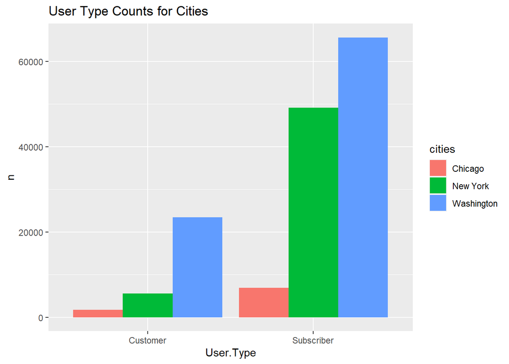

```r
ggplot(data.m, aes(fill=cities, y=n, x=User.Type)) + geom_col(position="dodge") + labs(title="User Type Counts for Cities")
```

From the above visualizations:

1. For New York, there are more subscribers than customers.
2. For Chicago, there are more subscribers than customers.
3. For Washington, there are more subscribers than customers.

Hence, more Subscribers use the service than customers

It’s as simple as that.

## A Little sidenote

When I was practicing how to program grouped bar plots, I didn’t have access to the dplyr library in the environment I was working on, so I wrote this little function to compute the counts for each user type.

```r
user_counts.function <- function(city_data) {
    aggregated_data <- aggregate(city_data$User.Type, by=list(city_data$User.Type), FUN=length)
    names(aggregated_data)[1] = "User.Type"
    names(aggregated_data)[2] = "Count"
    row.names(aggregated_data) <- NULL
    return (aggregated_data[2:nrow(aggregated_data), ])
}
```

We use the aggregate function and apply length function to aggregate by the User.Type column of the city_data parameter. Note: Use this only if for any reason you do not have access to the dplyr library.

Hope you enjoyed this post. Leave a comment below!